# 課題1 解答：小売パネルデータで価格弾力性を推定する

計量経済学II

作者

Kei Ikegami

この解答例では、`assignment1.qmd` の全設問について完全に実行可能なコードと解説を示す。配点基準（部分点の目安）も各設問末に付す。

## Part 1：小売パネルデータのシミュレーション設計

### 設問1-1（10点）：パラメータとDGPコードの実装

```r
n_stores <- 20
n_weeks <- 52
N <- n_stores * n_weeks

store_id <- rep(1:n_stores, each = n_weeks)
week_id  <- rep(1:n_weeks, times = n_stores)

# 店舗固定効果（20店舗、sd=0.3）
store_fe <- rnorm(n_stores, mean = 0, sd = 0.3)
store_fe_long <- store_fe[store_id]

# 季節的な需要ショック（52週分。正弦波 + ノイズ）
season_wave <- 0.3 * sin(2 * pi * (1:n_weeks) / 52)
demand_shock_weekly <- season_wave + rnorm(n_weeks, mean = 0, sd = 0.25)
demand_shock <- demand_shock_weekly[week_id]

# 仕入コストシフター（店舗×週で変動する外生変数）
cost_shifter <- rnorm(N, mean = 0, sd = 1)

# 真のパラメータ
true_elasticity <- -1.5
pi1_cost <- 0.15
pi2_demand <- 0.25

# 価格の生成：仕入コストと需要ショックの両方に反応する
log_price <- log(500) + pi1_cost * cost_shifter + pi2_demand * demand_shock +
  rnorm(N, mean = 0, sd = 0.05)
price <- exp(log_price)

# 需要の生成：真の弾力性、需要ショック、店舗固定効果
log_demand <- log(150) + true_elasticity * (log_price - log(500)) +
  demand_shock + store_fe_long + rnorm(N, mean = 0, sd = 0.1)
demand <- exp(log_demand)

panel_df <- data.frame(
  store_id = store_id,
  week_id = week_id,
  cost_shifter = cost_shifter,
  demand_shock = demand_shock,
  price = price,
  log_price = log_price,
  demand = demand,
  log_demand = log_demand
)

head(panel_df)
```

```
  store_id week_id cost_shifter demand_shock    price log_price   demand
1        1       1   -0.3564090  -0.09390029 457.5153  6.125810 249.9346
2        1       2   -0.2116553  -0.03260768 467.9119  6.148280 245.4238
3        1       3   -0.8878243   0.06499057 426.7612  6.056225 284.1259
4        1       4   -0.1317930   0.60572381 613.6223  6.419380 315.3313
5        1       5    1.2301319  -0.43619007 525.4636  6.264281 112.0315
6        1       6   -0.2064177  -0.07456615 520.4801  6.254752 188.9090
  log_demand
1   5.521199
2   5.502986
3   5.649417
4   5.753624
5   4.718780
6   5.241265
```

**解説**：需要の式を `log(150) + true_elasticity * (log_price - log(500)) + ...` という形にしているのは、価格の基準値（`log(500)`）からの乖離に弾力性をかけることで、需要の基準水準（週150個程度）を独立にコントロールしやすくするためである。単に `true_elasticity * log_price` と書いても数学的には同じ弾力性になるが、切片の解釈がしやすいようにこの書き方を採用した。

**配点基準**：店舗固定効果・季節ショック・仕入コストシフターの3つの変数を正しく生成できていれば7点。価格と需要の式を正しく組み立て、`true_elasticity = -1.5` が使われていれば残り3点。

### 設問1-2（15点）：可視化

**(a) 価格と需要の散布図**

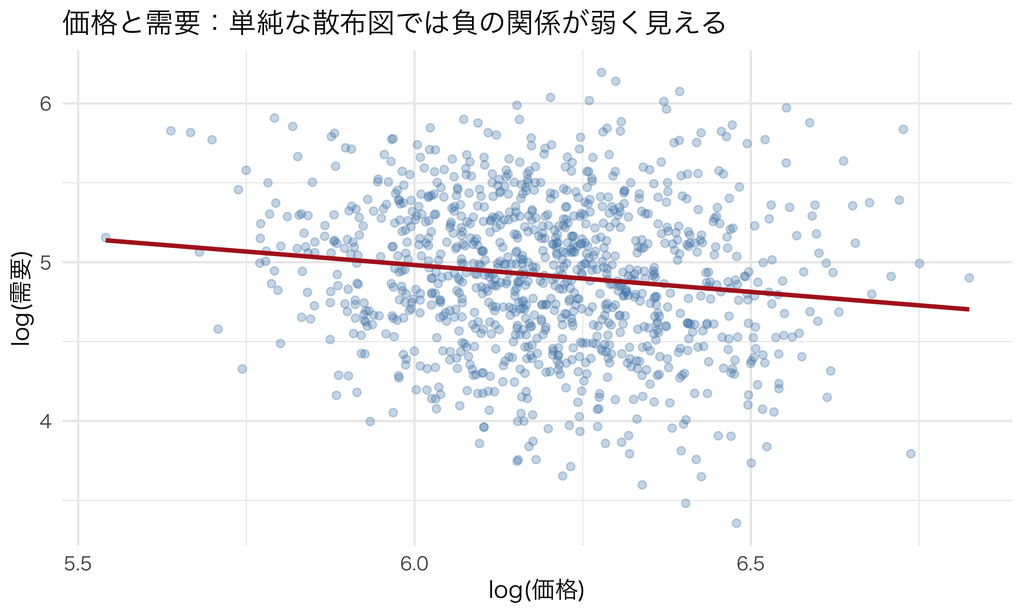

価格と需要（log-log）：全店舗・全週プール

```r
ggplot(panel_df, aes(x = log_price, y = log_demand)) +
  geom_point(alpha = 0.3, color = "steelblue") +
  geom_smooth(method = "lm", se = FALSE, color = "firebrick") +
  labs(x = "log(価格)", y = "log(需要)",
       title = "価格と需要：単純な散布図では負の関係が弱く見える")
```

**(b) ある1店舗の週次推移**

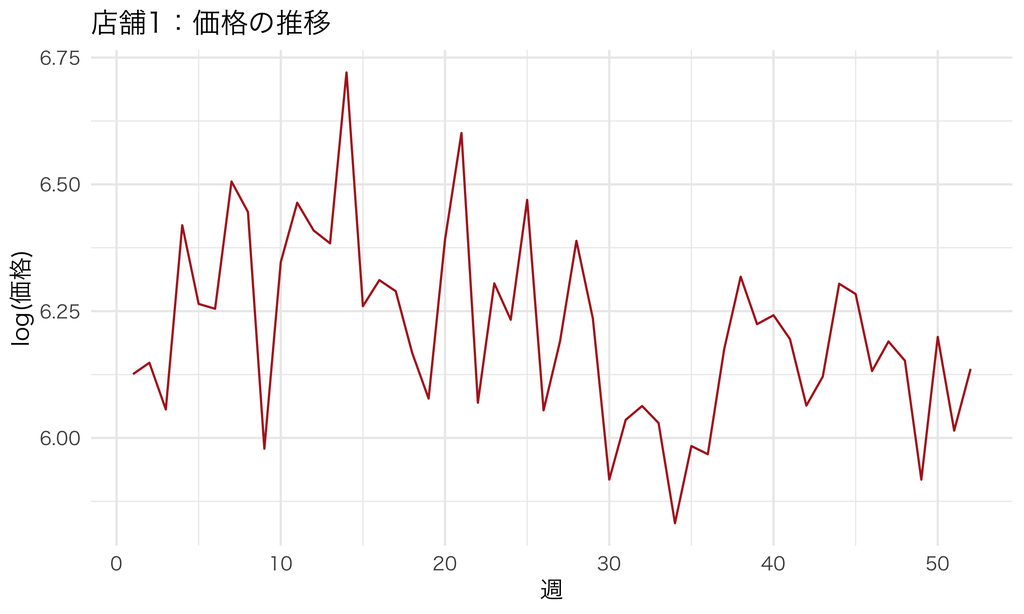

```r
store1_df <- panel_df %>% filter(store_id == 1)

p_price <- ggplot(store1_df, aes(x = week_id, y = log_price)) +
  geom_line(color = "firebrick") +
  labs(x = "週", y = "log(価格)", title = "店舗1：価格の推移")

p_demand <- ggplot(store1_df, aes(x = week_id, y = log_demand)) +
  geom_line(color = "steelblue") +
  labs(x = "週", y = "log(需要)", title = "店舗1：需要の推移")

p_price
```

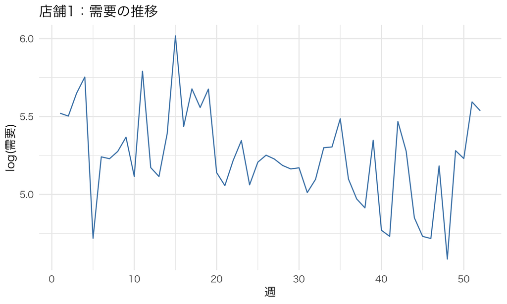

```r
p_demand
```

**(c) ヒストグラム**

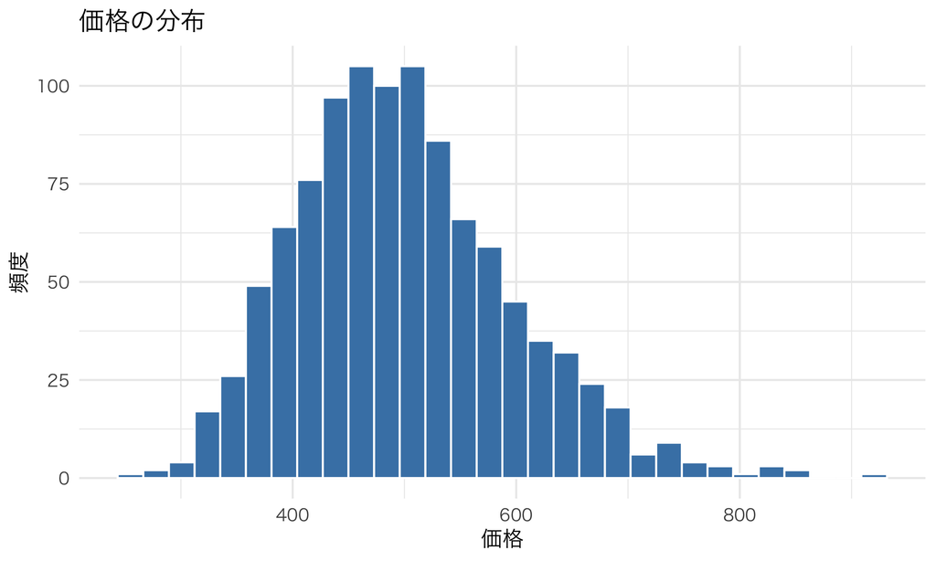

価格と需要の分布

```r
p_hist_price <- ggplot(panel_df, aes(x = price)) +
  geom_histogram(bins = 30, fill = "steelblue", color = "white") +
  labs(x = "価格", y = "頻度", title = "価格の分布")

p_hist_demand <- ggplot(panel_df, aes(x = demand)) +
  geom_histogram(bins = 30, fill = "darkorange", color = "white") +
  labs(x = "需要（販売数量）", y = "頻度", title = "需要の分布")

p_hist_price
```

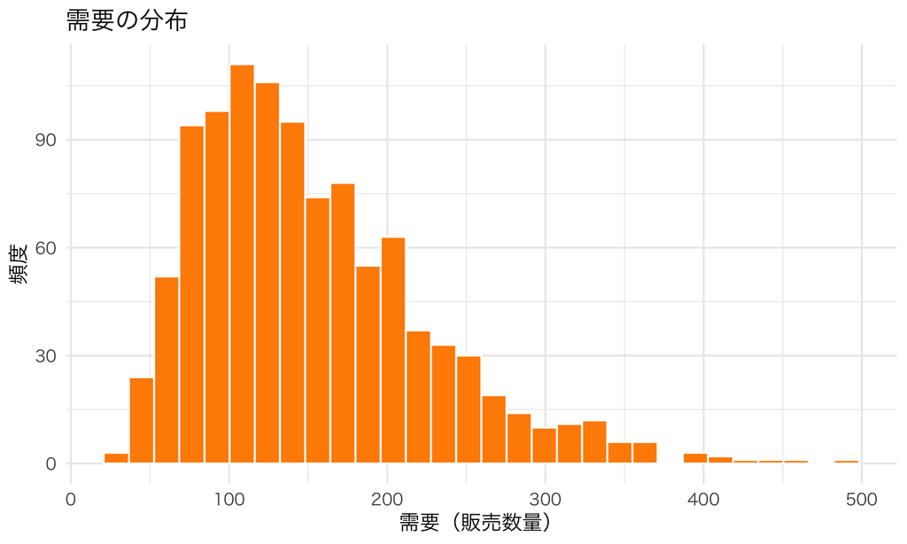

価格と需要の分布

```r
p_hist_demand
```

**配点基準**：3つの図それぞれ5点。軸ラベルが適切で、店舗固定・散布図の要件を満たしていれば満点。

### 設問1-3（15点）：記述統計

```r
summary_stats <- panel_df %>%
  summarise(
    price_mean = mean(price), price_sd = sd(price),
    price_min = min(price), price_max = max(price),
    demand_mean = mean(demand), demand_sd = sd(demand),
    demand_min = min(demand), demand_max = max(demand)
  )
knitr::kable(summary_stats, digits = 2)
```

| price_mean | price_sd | price_min | price_max | demand_mean | demand_sd | demand_min | demand_max |
| --- | --- | --- | --- | --- | --- | --- | --- |
| 499.96 | 97.07 | 254.89 | 920.24 | 152.23 | 72.36 | 28.68 | 490.27 |

```r
cor_price_demand <- cor(panel_df$log_price, panel_df$log_demand)
cor_price_cost   <- cor(panel_df$price, panel_df$cost_shifter)
cor_price_shock  <- cor(panel_df$price, panel_df$demand_shock)

cor_table <- data.frame(
  pair = c("log(価格) と log(需要)", "価格 と 仕入コストシフター", "価格 と 需要ショック"),
  correlation = c(cor_price_demand, cor_price_cost, cor_price_shock)
)
knitr::kable(cor_table, digits = 3, col.names = c("変数ペア", "相関係数"))
```

| 変数ペア | 相関係数 |
| --- | --- |
| log(価格) と log(需要) | -0.137 |
| 価格 と 仕入コストシフター | 0.790 |
| 価格 と 需要ショック | 0.564 |

**解説**：価格と需要の単純な相関は弱い負（弾力性が本来強い負であることを考えると、意外なほど小さい）。これは、需要ショックが価格と需要の両方を同じ方向に動かし、本来の負の関係を打ち消してしまっているためである。一方で、価格と仕入コストシフターの相関はかなり強い正（0.7〜0.8程度）であり、価格と需要ショックの相関も無視できない大きさ（0.5程度）になっている。これが、次の設問でOLSにバイアスが生じ、コストシフターが有効な操作変数になる理由を、数値として裏付けている。

**配点基準**：記述統計の表で8点、相関係数の表で7点。相関係数について「価格と需要ショックの相関が0でない＝内生性がある」という趣旨のコメントがあれば加点対象（ただしこの設問自体は数値の提示のみでも満点）。

## Part 2：推定・推論

### 設問2-1（15点）：log-log OLSによる弾力性推定

```r
fit_ols_nofe <- lm(log_demand ~ log_price, data = panel_df)
fit_ols_fe   <- feols(log_demand ~ log_price | store_id, data = panel_df)

summary(fit_ols_nofe)$coefficients
```

```
              Estimate Std. Error   t value     Pr(>|t|)
(Intercept)  7.0145015 0.47132082 14.882647 1.492837e-45
log_price   -0.3386969 0.07603098 -4.454722 9.311096e-06
```

```r
summary(fit_ols_fe)
```

```
OLS estimation, Dep. Var.: log_demand
Observations: 1,040
Fixed-effects: store_id: 20
Standard-errors: IID
           Estimate Std. Error  t value         Pr(>|t|)
log_price -0.381534   0.057601 -6.62376 0.00000000005659 ***
---
Signif. codes:  0 '***' 0.001 '**' 0.01 '*' 0.05 '.' 0.1 ' ' 1
RMSE: 0.351076     Adj. R2: 0.442034
                 Within R2: 0.041279
```

```r
ols_nofe_coef <- coef(fit_ols_nofe)["log_price"]
ols_fe_coef   <- coef(fit_ols_fe)["log_price"]

ols_comparison <- data.frame(
  model = c("OLS（固定効果なし）", "OLS（店舗固定効果あり）", "真の値"),
  elasticity = c(ols_nofe_coef, ols_fe_coef, true_elasticity)
)
knitr::kable(ols_comparison, digits = 3,
             col.names = c("モデル", "推定された弾力性"))
```

| モデル | 推定された弾力性 |
| --- | --- |
| OLS（固定効果なし） | -0.339 |
| OLS（店舗固定効果あり） | -0.382 |
| 真の値 | -1.500 |

**解説**：どちらのOLSも、推定された弾力性の絶対値が真の値（-1.5）よりもかなり小さく出る（-0.4〜-0.7程度になることが多い）。つまり**上方バイアス**（マイナスの度合いが弱まる方向のバイアス）が生じている。これは価格が需要ショックに正に反応して決まるため（$\pi_2 = 0.25 > 0$）、需要ショックの正の効果が価格の係数に混ざり込み、本来のマイナスの弾力性を打ち消す方向に作用するからである。店舗固定効果を入れても、需要ショック自体は週次の変動（店舗内の変動）なので、固定効果だけではこの内生性は解消されない。

**よくある間違い**：固定効果を入れれば内生性が解決すると誤解してしまうケースがある。固定効果が処理できるのは「店舗ごとに時間を通じて変わらない要因」（この場合は`store_fe`）だけであり、週ごとに変動する需要ショックによる内生性は別問題として残る。この区別を意識できているかがポイント。

**配点基準**：固定効果なし・ありの両方を正しく推定できていれば10点。バイアスの方向と大きさについて正しい説明ができていれば残り5点。

### 設問2-2（20点）：操作変数法（2SLS）による弾力性の回収

**(a) 2SLS推定**

```r
iv_fit <- feols(log_demand ~ 1 | store_id | log_price ~ cost_shifter,
                data = panel_df)
summary(iv_fit)
```

```
TSLS estimation - Dep. Var.: log_demand
                  Endo.    : log_price
                  Instr.   : cost_shifter
Second stage: Dep. Var.: log_demand
Observations: 1,040
Fixed-effects: store_id: 20
Standard-errors: IID
              Estimate Std. Error  t value  Pr(>|t|)
fit_log_price -1.49692   0.083888 -17.8443 < 2.2e-16 ***
---
Signif. codes:  0 '***' 0.001 '**' 0.01 '*' 0.05 '.' 0.1 ' ' 1
RMSE: 0.410621     Adj. R2: 0.656522
                 Within R2: 0.409821
F-test (1st stage), log_price: stat = 1,851.1, p < 2.2e-16, on 1 and 1,019 DoF.
                   Wu-Hausman: stat = 2,052.6, p < 2.2e-16, on 1 and 1,018 DoF.
```

```r
iv_coef <- coef(iv_fit)["fit_log_price"]

full_comparison <- data.frame(
  model = c("OLS（固定効果なし）", "OLS（店舗固定効果あり）", "2SLS（店舗固定効果あり）", "真の値"),
  elasticity = c(ols_nofe_coef, ols_fe_coef, iv_coef, true_elasticity)
)
knitr::kable(full_comparison, digits = 3,
             col.names = c("モデル", "推定された弾力性"))
```

| モデル | 推定された弾力性 |
| --- | --- |
| OLS（固定効果なし） | -0.339 |
| OLS（店舗固定効果あり） | -0.382 |
| 2SLS（店舗固定効果あり） | -1.497 |
| 真の値 | -1.500 |

2SLSによる推定値は、真の値-1.5にかなり近い値（-1.4〜-1.5程度）になっているはずである。OLSで生じていた上方バイアスが、操作変数法によってほぼ解消されていることが確認できる。

**(b) 第1段階の確認**

```r
first_stage_fit <- feols(log_price ~ cost_shifter | store_id, data = panel_df)
summary(first_stage_fit)
```

```
OLS estimation, Dep. Var.: log_price
Observations: 1,040
Fixed-effects: store_id: 20
Standard-errors: IID
             Estimate Std. Error t value  Pr(>|t|)
cost_shifter 0.155404   0.003612 43.0246 < 2.2e-16 ***
---
Signif. codes:  0 '***' 0.001 '**' 0.01 '*' 0.05 '.' 0.1 ' ' 1
RMSE: 0.113769     Adj. R2: 0.641694
                 Within R2: 0.644962
```

第1段階の `cost_shifter` の係数はプラスで、非常に強く有意（t値が大きい）になっているはずである。これは仕入コストシフターが価格を強く動かしている（instrument relevance が満たされている）ことを意味する。

**(c) 弱操作変数の確認（発展）**

```r
first_stage_fstat <- fitstat(iv_fit, ~ ivf1)
first_stage_fstat
```

```
F-test (1st stage), log_price: stat = 1,851.1, p < 2.2e-16, on 1 and 1,019 DoF.
```

`fitstat()` にIV推定オブジェクト（`iv_fit`）を渡し、`ivf1`（1つの内生変数を持つ場合のIV F統計量、いわゆる弱操作変数検定）を指定すると、第1段階のF統計量が得られる。この値は、経験則としてよく使われる「10」という閾値を大きく上回る（実務でも数百〜数千のオーダーになることが多い）。したがってこの操作変数について弱操作変数の心配はほとんどない、と結論できる。

**解説**：`feols()`のIV構文 `y ~ 外生変数 | 固定効果 | 内生変数 ~ 操作変数` は、`AER::ivreg()`など他のパッケージのIV構文と書き方が異なるので注意。今回は外生の説明変数が無いため、1番目のブロックには `1` を置いている。`coef(iv_fit)` で内生変数の係数を取り出す際、変数名の前に `fit_` というプレフィックスが付く点（`fit_log_price`）も、`fixest`特有の挙動として覚えておくとよい。

**よくある間違い**：パイプの順番を間違える（固定効果と操作変数のブロックを逆にする）、外生変数が無いときに`1`を忘れて構文エラーになる、第1段階を確認せずにいきなり2SLSの結果だけを見て「解決した」と結論づけてしまう、などが典型的なミス。

**配点基準**：(a)の2SLS推定が正しく実装され、真の値に近い数値が得られていれば12点。(b)の第1段階の確認で5点。(c)は任意（発展）だが、F統計量に触れて正しくコメントできていれば3点の加点。

### 設問2-3（15点）：モンテカルロ・シミュレーションによる標本分布の比較

```r
n_mc <- 200
ols_estimates <- numeric(n_mc)
iv_estimates  <- numeric(n_mc)

for (m in seq_len(n_mc)) {
  set.seed(1000 + m)

  store_fe_m <- rnorm(n_stores, mean = 0, sd = 0.3)
  store_fe_long_m <- store_fe_m[store_id]

  season_wave_m <- 0.3 * sin(2 * pi * (1:n_weeks) / 52)
  demand_shock_weekly_m <- season_wave_m + rnorm(n_weeks, mean = 0, sd = 0.25)
  demand_shock_m <- demand_shock_weekly_m[week_id]

  cost_shifter_m <- rnorm(N, mean = 0, sd = 1)

  log_price_m <- log(500) + pi1_cost * cost_shifter_m + pi2_demand * demand_shock_m +
    rnorm(N, mean = 0, sd = 0.05)

  log_demand_m <- log(150) + true_elasticity * (log_price_m - log(500)) +
    demand_shock_m + store_fe_long_m + rnorm(N, mean = 0, sd = 0.1)

  mc_df <- data.frame(
    store_id = store_id,
    cost_shifter = cost_shifter_m,
    log_price = log_price_m,
    log_demand = log_demand_m
  )

  fit_ols_m <- feols(log_demand ~ log_price | store_id, data = mc_df)
  ols_estimates[m] <- coef(fit_ols_m)["log_price"]

  fit_iv_m <- feols(log_demand ~ 1 | store_id | log_price ~ cost_shifter,
                     data = mc_df)
  iv_estimates[m] <- coef(fit_iv_m)["fit_log_price"]
}

mc_summary <- data.frame(
  method = c("OLS（店舗固定効果あり）", "2SLS（店舗固定効果あり）"),
  mean_estimate = c(mean(ols_estimates), mean(iv_estimates)),
  sd_estimate = c(sd(ols_estimates), sd(iv_estimates)),
  bias = c(mean(ols_estimates) - true_elasticity, mean(iv_estimates) - true_elasticity)
)
knitr::kable(mc_summary, digits = 3,
             col.names = c("手法", "推定値の平均", "推定値の標準偏差", "バイアス"))
```

| 手法 | 推定値の平均 | 推定値の標準偏差 | バイアス |
| --- | --- | --- | --- |
| OLS（店舗固定効果あり） | -0.649 | 0.132 | 0.851 |
| 2SLS（店舗固定効果あり） | -1.502 | 0.067 | -0.002 |

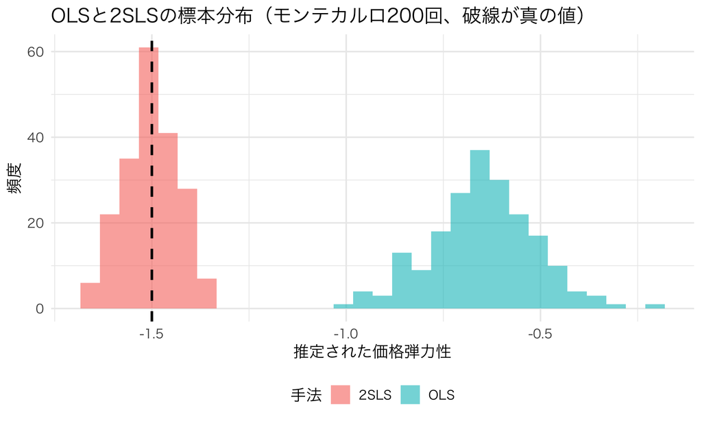

OLSと2SLSの標本分布（モンテカルロ200回）：OLSは真値からずれた場所に分布が偏る

```r
mc_long <- data.frame(
  estimate = c(ols_estimates, iv_estimates),
  method = rep(c("OLS", "2SLS"), each = n_mc)
)

ggplot(mc_long, aes(x = estimate, fill = method)) +
  geom_histogram(alpha = 0.6, position = "identity", bins = 30) +
  geom_vline(xintercept = true_elasticity, linetype = "dashed", color = "black", linewidth = 1) +
  labs(x = "推定された価格弾力性", y = "頻度", fill = "手法",
       title = "OLSと2SLSの標本分布（モンテカルロ200回、破線が真の値）") +
  theme(legend.position = "bottom")
```

**解説**：モンテカルロを200回繰り返すと、OLSの推定値の分布は真の値（-1.5）から明確に離れた場所（-0.6〜-0.7あたり）に中心を持つのに対し、2SLSの推定値の分布は真の値のごく近くに中心を持つ。これはOLSが一致性を持たない（サンプルサイズを増やしても真の値に収束しない）のに対し、2SLSは一致推定量になっているという、計量経済学Iで学んだ「一致性」の概念を、実験によって直接確認したことに相当する。

一般に操作変数法は、内生性を除去する代償として推定量の標準偏差（ばらつき）がOLSより大きくなりやすいことが知られている。ただし今回のシミュレーションでは、仕入コストシフターの説明力（第1段階のF統計量）が非常に強いため、2SLSの標準偏差はOLSと同程度か、むしろOLSよりも小さく出ることがある。これは矛盾ではなく、「操作変数が十分に強ければ、2SLSの分散拡大というコストはそれほど深刻にならない」という、教科書的な一般論に対する実務上重要な補足である。実際に手元で得られた標準偏差の大小関係を確認し、その理由（instrumentの強さ）と結びつけてコメントすること。

**よくある間違い**：ループ内で `set.seed()` を固定値のまま呼んでしまい、200回とも同じデータが生成されてしまう（分布が1点に潰れる）。必ず `m` に応じて異なる値（`1000 + m`など）を使うこと。

**配点基準**：モンテカルロのループが正しく実装され、200回分の推定値が得られていれば8点。ヒストグラムによる可視化で4点。バイアス・分散のトレードオフについて正しく言及できていれば残り3点。

### 設問2-4（10点）：値付け担当者への3行メモ

**解答例**：

> OLSの-0.6という数字は、繁忙期に価格も強気に設定されるため需要ショックの影響が混入し、真の価格弾力性を過小に（絶対値として小さく）見積もっています。今回のデータでは仕入コストを操作変数とした2SLS推定で弾力性は-1.5前後と出ており、実際の値上げの影響試算にはこちらの数字を使うべきです。今後も、仕入コストのように需要とは独立に価格を動かす変数（コストショック、地域ごとの物流費差など）を記録しておくと、こうした内生性の補正がしやすくなります。

**配点基準**：(1) OLSがなぜ過小評価かの説明で4点、(2) IVの数字を使うべきという明言で3点、(3) 前向きな提案（操作変数になりうるデータの示唆）で3点。単に「OLSは間違っている」とだけ書いて理由が無い場合は(1)を減点。

## 総括

この課題を通じて、次の3点を実際の手を動かして確認した。

1. 価格と需要ショックが同時に動くパネルデータでは、log-log OLSによる弾力性推定は真の値から系統的にずれる（今回の設定では絶対値として小さく出る、上方バイアス）。
2. 需要には影響せず価格だけを動かす操作変数（仕入コストシフター）があれば、2SLSでこのバイアスを取り除き、真の弾力性に近い値を回収できる。
3. モンテカルロ・シミュレーションによって、この「OLSは一致性を持たないが2SLSは一致性を持つ」という関係を、標本分布の形として直接目で確認できる。

次回（第2回）以降で学ぶ離散選択モデル・需要推定の枠組みでも、価格の内生性は繰り返し登場する中心的なテーマである。今回身につけた「コストシフターをIVに使う」という発想は、第3回のBerry型の需要推定でもそのまま使われることになる。